# Ramdon Forest -- Batch Learning

### Authors

- Romero Romero, Martin
- Izquierdo Alvarez, Mario
- Ortega Pinto, Valentina
- Giménez López, Antonio

# Importing needed libraries

```python
import os
import sys

utils_path = os.path.abspath('../utils/')
if utils_path not in sys.path:
    sys.path.append(utils_path)
```

```python
import pandas as pd
from rich import print
import matplotlib.pyplot as plt
import seaborn as sns
from tqdm import tqdm
import numpy as np
import csv
from data_visualization import *
```

# Loading and preparing the dataset

Load the dataset, split the dataset into a training set and a test set, train with ML method, and then evaluate. This should provide a baseline for understanding default ML parameters.

```python
# Loading data in a pandas DataFrame
csv_file_path = '../data/prepared_miningProcess_data_agg.csv'
df = pd.read_csv(csv_file_path)
```

```python
# Sorting data by date
df['date'] = pd.to_datetime(df['date'], format='%Y-%m-%d %H:%M:%S')

df = df.sort_values(by='date')
df
```

|  | date | % Iron Feed | % Silica Feed | Starch Flow | Amina Flow | Ore Pulp Flow | Ore Pulp pH | Ore Pulp Density | Flotation Column 01 Air Flow | Flotation Column 02 Air Flow | ... | Flotation Column 07 Air Flow | Flotation Column 01 Level | Flotation Column 02 Level | Flotation Column 03 Level | Flotation Column 04 Level | Flotation Column 05 Level | Flotation Column 06 Level | Flotation Column 07 Level | % Iron Concentrate | % Silica Concentrate |
| --- | --- | --- | --- | --- | --- | --- | --- | --- | --- | --- | --- | --- | --- | --- | --- | --- | --- | --- | --- | --- | --- |
| 0 | 2017-03-10 01:00:00 | 55.20 | 16.98 | 3162.625026 | 578.786678 | 398.753368 | 10.113487 | 1.729558 | 251.166672 | 250.226086 | ... | 250.208184 | 450.383776 | 446.891845 | 450.474523 | 449.912259 | 455.792161 | 464.383310 | 450.532747 | 66.91 | 1.31 |
| 1 | 2017-03-10 02:00:00 | 55.20 | 16.98 | 3133.256389 | 537.219661 | 399.871822 | 10.129742 | 1.667784 | 249.880589 | 250.214050 | ... | 249.897572 | 449.373361 | 450.249356 | 450.081222 | 450.328806 | 448.722983 | 455.501528 | 451.387700 | 67.06 | 1.11 |
| 2 | 2017-03-10 03:00:00 | 55.20 | 16.98 | 3479.482944 | 591.906744 | 398.763806 | 10.048403 | 1.732711 | 250.161328 | 250.104167 | ... | 250.484183 | 449.972878 | 450.868711 | 450.901822 | 451.145822 | 451.134189 | 459.981311 | 450.296722 | 66.97 | 1.27 |
| 3 | 2017-03-10 04:00:00 | 55.20 | 16.98 | 3228.036436 | 593.170106 | 399.866983 | 9.918614 | 1.731056 | 250.208772 | 250.204761 | ... | 250.157622 | 487.940706 | 491.462111 | 487.387206 | 494.528183 | 495.664011 | 502.763850 | 494.939889 | 66.75 | 1.36 |
| 4 | 2017-03-10 05:00:00 | 55.20 | 16.98 | 3327.280739 | 619.710806 | 399.615089 | 9.746029 | 1.765879 | 249.917800 | 250.160494 | ... | 250.078639 | 549.031539 | 549.983156 | 549.459572 | 549.975483 | 549.512533 | 560.696300 | 550.271772 | 66.63 | 1.34 |
| ... | ... | ... | ... | ... | ... | ... | ... | ... | ... | ... | ... | ... | ... | ... | ... | ... | ... | ... | ... | ... | ... |
| 4092 | 2017-09-09 19:00:00 | 49.75 | 23.20 | 3327.047776 | 497.211189 | 380.847200 | 9.176166 | 1.660871 | 301.565561 | 300.169133 | ... | 298.736661 | 397.781583 | 498.753311 | 403.858956 | 398.930467 | 502.971728 | 399.468911 | 400.559511 | 65.05 | 1.65 |
| 4093 | 2017-09-09 20:00:00 | 49.75 | 23.20 | 4225.800333 | 508.963856 | 381.112889 | 9.387541 | 1.691996 | 300.050172 | 299.967839 | ... | 303.599269 | 399.928567 | 499.648950 | 399.208611 | 399.967122 | 501.624533 | 398.905006 | 400.486233 | 64.83 | 1.71 |
| 4094 | 2017-09-09 21:00:00 | 49.75 | 23.20 | 2808.214692 | 517.748822 | 381.064411 | 9.771277 | 1.735647 | 299.814289 | 299.801561 | ... | 309.875439 | 399.961433 | 500.484917 | 471.827489 | 399.931033 | 500.223311 | 401.899806 | 400.556333 | 64.29 | 1.80 |
| 4095 | 2017-09-09 22:00:00 | 49.75 | 23.20 | 3191.497672 | 492.511228 | 380.445006 | 9.782121 | 1.716644 | 300.122756 | 299.679472 | ... | 305.254558 | 399.601383 | 498.614494 | 836.277192 | 400.455389 | 500.406239 | 402.703283 | 401.769072 | 64.25 | 1.96 |
| 4096 | 2017-09-09 23:00:00 | 49.75 | 23.20 | 3638.543653 | 460.769950 | 380.823147 | 9.653802 | 1.667826 | 299.778889 | 300.095394 | ... | 315.264733 | 400.026289 | 499.721794 | 868.549247 | 398.764744 | 500.682167 | 399.375644 | 398.775261 | 64.27 | 1.71 |

4097 rows × 24 columns

## Correlation without % Iron Concentrate

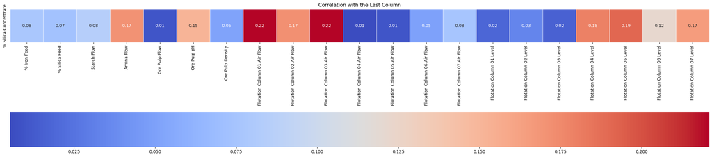

```python
df_without_IronCon = df.drop(['date', '% Iron Concentrate' ], axis=1)

corr_matrix = df_without_IronCon.corr().abs()

# Lets plot only correlation with the class, without considering itself for better localization of the most correlated features
target_corr = corr_matrix.iloc[:-1, -1]

# Creating a df for using seaborn
target_corr_df = target_corr.to_frame().transpose()

plt.figure(figsize=(30, 20))
sns.heatmap(target_corr_df, annot=True, fmt=".2f", cmap='coolwarm', square=True, linewidths=.5, cbar_kws={"orientation": "horizontal"})
plt.title('Correlation with the Last Column')
plt.show()
```

```python
#Separating targets from inputs
df_inputs = df.columns.drop(['date','% Iron Concentrate','% Silica Concentrate','% Iron Feed', '% Silica Feed', 'Starch Flow', 'Amina Flow', 'Ore Pulp Flow', 'Ore Pulp pH',
                                                           'Ore Pulp Density',
                                                           'Flotation Column 04 Air Flow', 'Flotation Column 05 Air Flow', 'Flotation Column 06 Air Flow', 'Flotation Column 07 Air Flow',
                                                           'Flotation Column 01 Level', 'Flotation Column 02 Level', 'Flotation Column 03 Level',
                                                           'Flotation Column 06 Level'])
df_targets = df[['% Silica Concentrate']]
```

**Thirty-three percent** of the samples were selected as a **test set**, respecting the **time series** of the data, so that the **regression error** calculated on these batch learning data can be **compared** with the error values obtained in the online learning models on the corresponding instances in the data stream.

```python
# Splitting the dataset into a training set and a test set
train_size = int(len(df)*(1-0.33))

x_train, x_test = df[df_inputs].iloc[:train_size], df[df_inputs].iloc[train_size:]
y_train, y_test = df_targets.iloc[:train_size], df_targets.iloc[train_size:]
```

```python
x_trained = np.ravel(x_train)
y_trained = np.ravel(y_train)
```